# Module_11_maf_tools

Nick Chevalier

2023-12-11

## 1) Introduction

Mutation Annotation Format (MAF) is being widely accepted and used to store somatic variants detected. The Cancer Genome Atlas Project has sequenced over 30 different cancers with sample size of each cancer type being over 200. The Resulting data consisting of somatic variants are stored in the form of Mutation Annotation Format. This package attempts to summarize, analyze, annotate and visualize MAF files in an efficient manner from either TCGA sources or any in-house studies as long as the data is in MAF format.

## 2) Generating MAF

If have VCF files or simple tabular files, then can use vcf2maf utility This will annotate VCFs, prioritize transcripts, and generates an MAF. Recent updates to gatk has also enabled funcotator to genrate MAF files. If using ANNOVAR for variant annotations, maftools has a handy function annovarToMaf for converting tabular annovar outputs to MAF.

## 6) Reading and Summarizing maf files

### 6.1 Input files

an MAF file - can be gz compressed. Required. an optional but recommended clinical data associated with each sample/Tumor_Sample_Barcode in MAF. an optional copy number data if available. Can be GISTIC output or a custom table containing sample names, gene names and copy-number status (Amp or Del).

### 6.2 Reading MAF files

```r
library("maftools")
#path to TCGA LAML MAF file
laml.maf = system.file('extdata', 'tcga_laml.maf.gz', package = 'maftools')
#clinical information containing survival information and histology. This is optional
laml.clin = system.file('extdata', 'tcga_laml_annot.tsv', package = 'maftools')

laml = read.maf(maf = laml.maf, clinicalData = laml.clin)
```

```
## -Reading
## -Validating
## -Silent variants: 475
## -Summarizing
## -Processing clinical data
## -Finished in 0.108s elapsed (0.098s cpu)
```

read.maf function reads MAF files, summarizes it in various ways and stores it as an MAF object. Even though MAF file is alone enough, it is recommended to provide annotations associated with samples in MAF. One can also integrate copy number data if available.

Note that by default, Variants with High/Moderate consequences are considered as non-synonymous. You change this behavior with the argument vc_nonSyn in read.maf.

### 6.3 MAF Object

```r
# Show the basic summary of MAF file.
laml
```

```
## An object of class  MAF
##                    ID          summary  Mean Median
##  1:        NCBI_Build               37    NA     NA
##  2:            Center genome.wustl.edu    NA     NA
##  3:           Samples              193    NA     NA
##  4:            nGenes             1241    NA     NA
##  5:   Frame_Shift_Del               52 0.269      0
##  6:   Frame_Shift_Ins               91 0.472      0
##  7:      In_Frame_Del               10 0.052      0
##  8:      In_Frame_Ins               42 0.218      0
##  9: Missense_Mutation             1342 6.953      7
## 10: Nonsense_Mutation              103 0.534      0
## 11:       Splice_Site               92 0.477      0
## 12:             total             1732 8.974      9
```

```r
#Shows sample summry.
getSampleSummary(laml)
```

```
##      Tumor_Sample_Barcode Frame_Shift_Del Frame_Shift_Ins In_Frame_Del
##   1:         TCGA-AB-3009               0               5            0
##   2:         TCGA-AB-2807               1               0            1
##   3:         TCGA-AB-2959               0               0            0
##   4:         TCGA-AB-3002               0               0            0
##   5:         TCGA-AB-2849               0               1            0
##  ---
## 189:         TCGA-AB-2942               0               0            0
## 190:         TCGA-AB-2946               0               0            0
## 191:         TCGA-AB-2954               0               0            0
## 192:         TCGA-AB-2982               0               0            0
## 193:         TCGA-AB-2903               0               0            0
##      In_Frame_Ins Missense_Mutation Nonsense_Mutation Splice_Site total
##   1:            1                25                 2           1    34
##   2:            0                16                 3           4    25
##   3:            0                22                 0           1    23
##   4:            0                15                 1           5    21
##   5:            0                16                 1           2    20
##  ---
## 189:            1                 0                 0           0     1
## 190:            0                 1                 0           0     1
## 191:            0                 1                 0           0     1
## 192:            0                 1                 0           0     1
## 193:            0                 0                 0           0     0
```

```r
#Shows gene summary.
getGeneSummary(laml)
```

```
##       Hugo_Symbol Frame_Shift_Del Frame_Shift_Ins In_Frame_Del In_Frame_Ins
##    1:        FLT3               0               0            1           33
##    2:      DNMT3A               4               0            0            0
##    3:        NPM1               0              33            0            0
##    4:        IDH2               0               0            0            0
##    5:        IDH1               0               0            0            0
##   ---
## 1237:      ZNF689               0               0            0            0
## 1238:      ZNF75D               0               0            0            0
## 1239:      ZNF827               1               0            0            0
## 1240:       ZNF99               0               0            0            0
## 1241:        ZPBP               0               0            0            0
##       Missense_Mutation Nonsense_Mutation Splice_Site total MutatedSamples
##    1:                15                 0           3    52             52
##    2:                39                 5           6    54             48
```

[output cut: 21 more lines]

```r
#shows clinical data associated with samples
getClinicalData(laml)
```

```
##      Tumor_Sample_Barcode FAB_classification days_to_last_followup
##   1:         TCGA-AB-2802                 M4                   365
##   2:         TCGA-AB-2803                 M3                   792
##   3:         TCGA-AB-2804                 M3                  2557
##   4:         TCGA-AB-2805                 M0                   577
##   5:         TCGA-AB-2806                 M1                   945
##  ---
## 189:         TCGA-AB-3007                 M3                  1581
## 190:         TCGA-AB-3008                 M1                   822
## 191:         TCGA-AB-3009                 M4                   577
## 192:         TCGA-AB-3011                 M1                  1885
## 193:         TCGA-AB-3012                 M3                  1887
##      Overall_Survival_Status
##   1:                       1
##   2:                       1
##   3:                       0
##   4:                       1
##   5:                       1
##  ---
## 189:                       0
## 190:                       1
## 191:                       1
## 192:                       0
## 193:                       0
```

```r
#Shows all fields in MAF
getFields(laml)
```

```
##  [1] "Hugo_Symbol"            "Entrez_Gene_Id"         "Center"
##  [4] "NCBI_Build"             "Chromosome"             "Start_Position"
##  [7] "End_Position"           "Strand"                 "Variant_Classification"
## [10] "Variant_Type"           "Reference_Allele"       "Tumor_Seq_Allele1"
## [13] "Tumor_Seq_Allele2"      "Tumor_Sample_Barcode"   "Protein_Change"
## [16] "i_TumorVAF_WU"          "i_transcript_name"
```

```r
#Writes maf summary to an output file with basename laml.
write.mafSummary(maf = laml, basename = 'laml')
```

Summarized MAF file is stored as an MAF object. MAF object contains main maf file, summarized data and any associated sample annotations. There are accessor methods to access the useful slots from MAF object.

## 7 Visualization

### 7.1 Plotting MAF summary

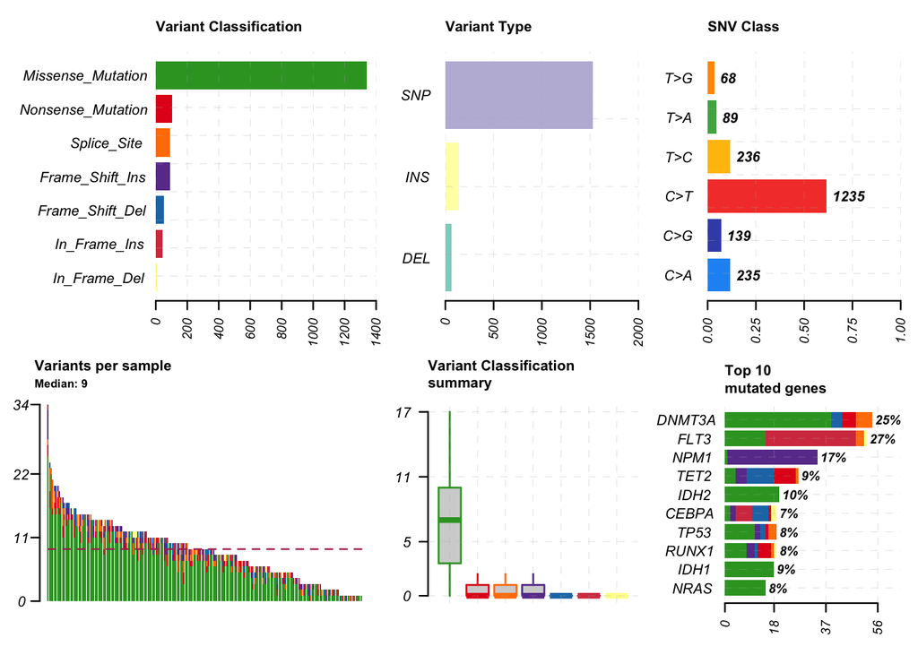

```r
plotmafSummary(maf = laml, rmOutlier = TRUE, addStat = 'median', dashboard = TRUE, titvRaw = FALSE)
```

Use plotmafSummary to plot the summary of the maf file, which displays number of variants in each sample as a stacked barplot and variant types as a boxplot summarized by Variant_Classification.

### 7.2 Onccoplots

#### 7.2.1 Drawing oncoplots

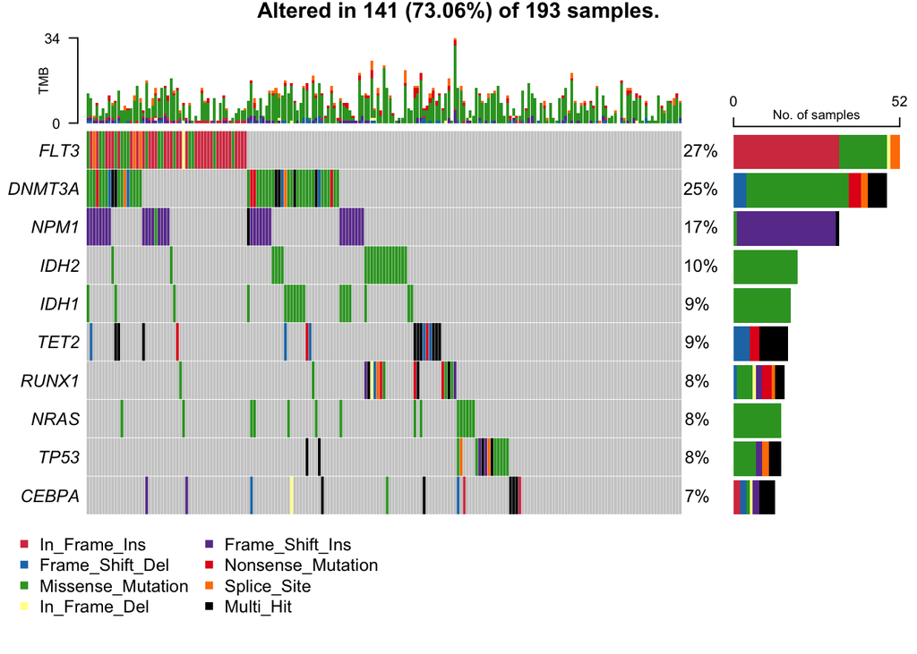

```r
# oncoplot for top ten mutated genes
oncoplot(maf = laml, top = 10)
```

Using oncoplot function to create waterfall plots and better represent maf file. Variants annotated as Multi_Hit are those genes which are mutated more than once in the same sample

### 7.3 Transition and Transversions

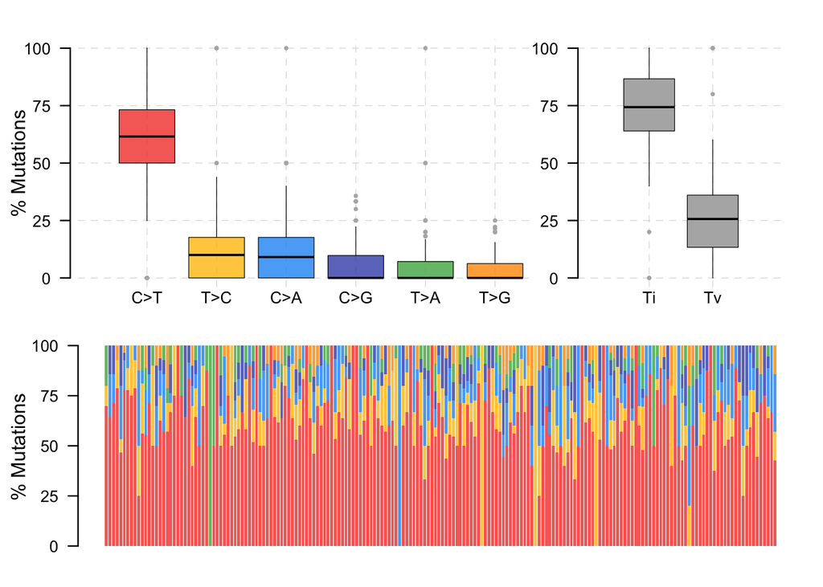

```r
laml.titv = titv(maf = laml, plot = FALSE, useSyn = TRUE)
#plot titv summary
plotTiTv(res = laml.titv)
```

titv function classifies SNPs into transitions and transversions and returns a list of summarized tables in various ways. -Transitions are the changing of 2 purines or of 2 pyrimidines (Base changes of similar shape): purines: A->G or G<->A (2 rings) pyrimidines: C->T or T->C (1 ring) -Transversions are interchanges of purine for pyrimidine: purine change to pyrimidine: G->C/T and A->C/T or pyrimidine change to purine: C->A/G and T->A/G There are 2x transversion options compared to transitions. However, transition mutations are generated at higher frequency than transversions. Transitions are less likely to result in AA substitution (due to wobble point) - usually silent substitutions in SNPs (single nucleotide polymorphisms)

### 7.4 Lollipop plots for amino acid changes

Lollipop plots uses AA change information in the maf file. MAF files have no clear guidelines on naming the field for AA changes. -different studies have different field (column) names for AA changes By default, lollipopPlot looks for column AAChange, and if it is not found in the MAF, it prints all available fields with warning message.

Below example, MAF file contains AA changes under a field/column name ‘Protein_Change’. Manually specify this using AACol #### 7.4.1 MAF as an input

```
## 3 transcripts available. Use arguments refSeqID or proteinID to manually specify tx name.
```

```
##      HGNC refseq.ID protein.ID aa.length
## 1: DNMT3A NM_022552  NP_072046       912
## 2: DNMT3A NM_153759  NP_715640       723
## 3: DNMT3A NM_175629  NP_783328       912
```

```
## Using longer transcript NM_022552 for now.
```

```
## Removed 3 mutations for which AA position was not available
```

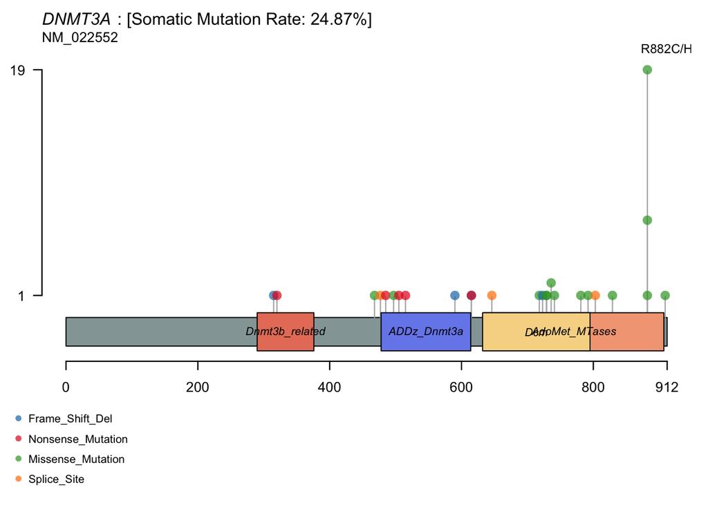

```r
#lollipop plot for DNMT3A, which is one of the most frequent mutated gene in Leukemia.
lollipopPlot(
  maf = laml,
  gene = 'DNMT3A',
  AACol = 'Protein_Change',
  showMutationRate = TRUE,
  labelPos = 882
)
```

#### 7.4.2 Custom data as an input

```r
#example data
my_data = data.frame(pos = sample.int(912, 15, replace = TRUE), count = sample.int(30, 15, replace = TRUE))
my_data
```

```
##    pos count
## 1  717     3
## 2  723    19
## 3  310     5
## 4  178     3
## 5  604     5
## 6  876     6
## 7   36     3
## 8   56    21
## 9  134    12
## 10 694     2
## 11 888    23
## 12  86    24
## 13 283    22
## 14 203     5
## 15 103    25
```

```
## 3 transcripts available. Use arguments refSeqID or proteinID to manually specify tx name.
```

```
##      HGNC refseq.ID protein.ID aa.length
## 1: DNMT3A NM_022552  NP_072046       912
## 2: DNMT3A NM_153759  NP_715640       723
## 3: DNMT3A NM_175629  NP_783328       912
```

```
## Using longer transcript NM_022552 for now.
```

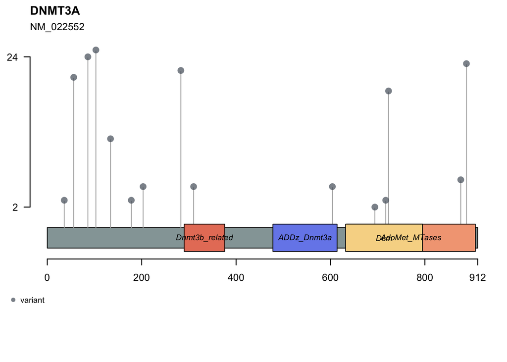

```r
lollipopPlot(data = my_data, gene = "DNMT3A")
```

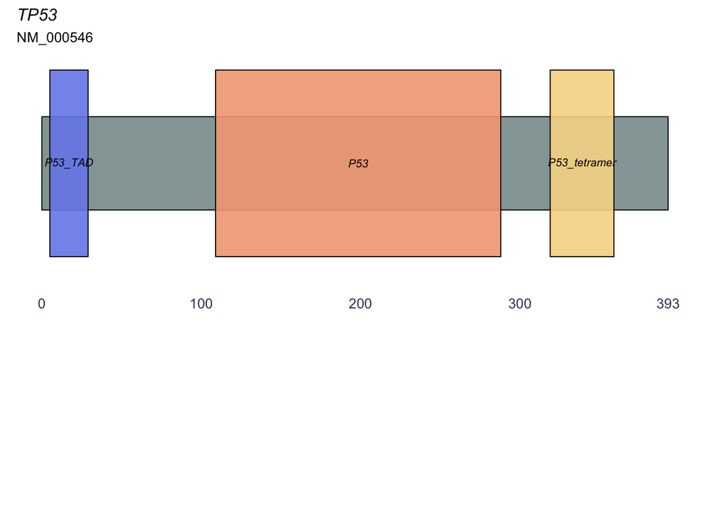

```r
# lollipopPlot documentation example using the TCGA laml data:
#laml.maf <- system.file("extdata", "tcga_laml.maf.gz", package = "maftools")
#laml <- read.maf(maf = laml.maf)
#lollipopPlot(maf = laml, gene = 'KIT', AACol = 'Protein_Change')

# plot general protein domains
plotProtein(gene = "TP53", refSeqID = "NM_000546")
```

### 7.5 Rainfall plots

Cancer genomes, especially solid tumors are characterized by genomic loci with localized hyper-mutations. Such hyper mutated genomic regions can be visualized by plotting INTER variant distance on a linear genomic scale - rainfall detectChangePoints is set to TRUE, rainfall plot also highlights regions where potential changes in inter-event distances are located.

```
## Processing TCGA-A8-A08B..
```

```
## Kataegis detected at:
```

```
##    Chromosome Start_Position End_Position nMuts Avg_intermutation_dist Size
## 1:          8       98129348     98133560     7               702.0000 4212
## 2:          8       98398549     98403536     9               623.3750 4987
## 3:          8       98453076     98456466     9               423.7500 3390
## 4:          8      124090377    124096810    22               306.3333 6433
## 5:         12       97436055     97439705     7               608.3333 3650
## 6:         17       29332072     29336153     8               583.0000 4081
##    Tumor_Sample_Barcode C>G C>T
## 1:         TCGA-A8-A08B   4   3
## 2:         TCGA-A8-A08B   1   8
## 3:         TCGA-A8-A08B   1   8
## 4:         TCGA-A8-A08B   1  21
## 5:         TCGA-A8-A08B   4   3
## 6:         TCGA-A8-A08B   4   4
```

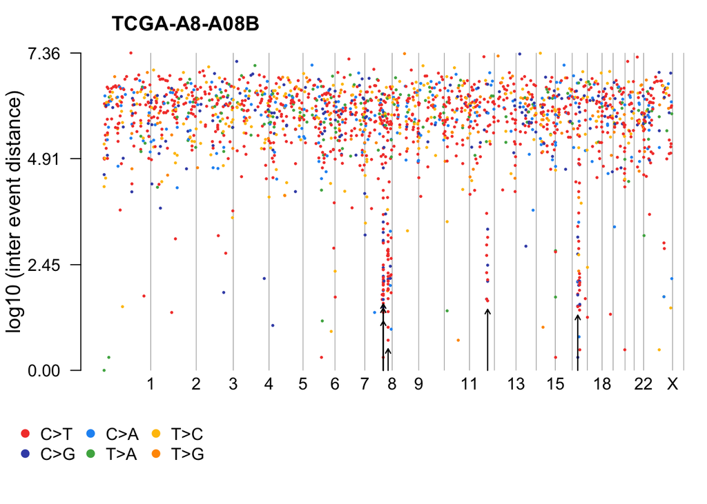

```r
brca <- system.file("extdata", "brca.maf.gz", package = "maftools")
brca = read.maf(maf = brca, verbose = FALSE)

rainfallPlot(maf = brca, detectChangePoints = TRUE, pointSize = 0.4)
```

### 7.6 Compare Mutation load against TCGA cohorts

tsgaCompare uses mutation load from TCGA MC3 for comparing mutation burden against 33 TCGA cohorts. Plot generates is similar to the one described in Alexandrob et al.

```r
laml.mutload = tcgaCompare(maf = laml, cohortName = 'Example=LAML', logscale = TRUE, capture_size = 50)
```

```
## Capture size [TCGA]:  35.8
```

```
## Capture size [Input]: 50
```

```
## Performing pairwise t-test for differences in mutation burden (per MB)..
```

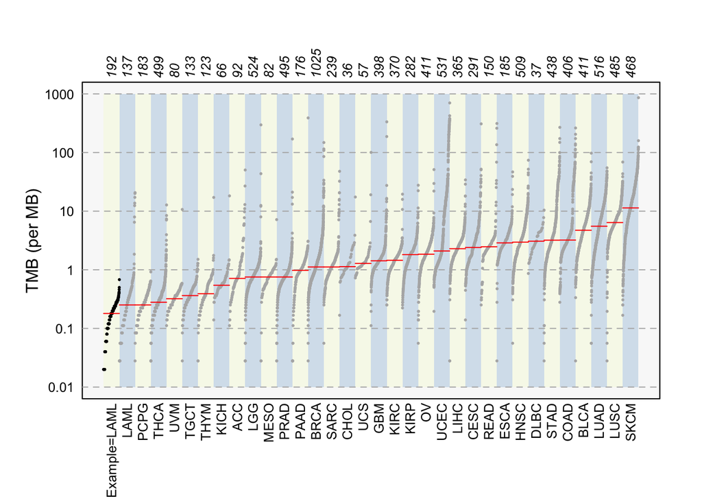

### 7.7 Plotting VAF

This function plots Variant Allele Frequencies as a boxplot which quickly helps estimate the clonal status of top mutated genes (clonal genes usually have mean allele frequency around ~50% assuming pure sample)

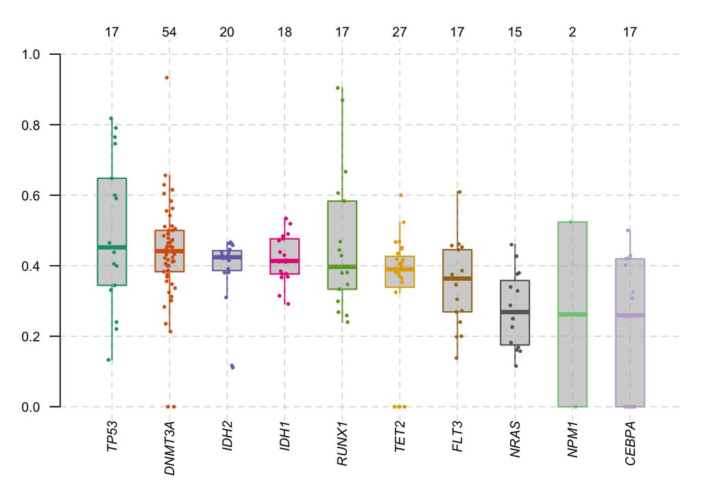

```r
plotVaf(maf = laml, vafCol = 'i_TumorVAF_WU')
```